# What are we even doing here?

POLS 602  
Fall 2026

Mike Burnham

Texas A&M University

## Announcements etc.

- Send in your github repo
- Don’t have ugly slides
- Use AI well

# Causal Inference

## Why is this important?

- Distinguish between correlation and explanation
- Epistemic justification
- Ground explanation in intervention
- Prediction

## Today

- Causal effects
- Functions
- Treatment and outcome variables
- Individual causal effects
- Average causal effects
- Randomized experiments
- Difference-in-means estimator

## Causal Effects

- Why do countries go to war?
- Why do insurgencies start?
- What increases voter turnout?
- Which education policies improve student outcomes?

## Functions

*A rule that relates one quantity to another*

$$f: X \to Y \qquad Y = f(X)$$

## Treatment Variable

*The variable whose change may produce a change in the outcome. The variable where the change originates.*

## Outcome/Dependent Variable

*The variable that may change in response to a change in the treatment variable.*

## Notation For Causal Relationships

- $X$ — the treatment variable
- $Y$ — the outcome variable
- $X \to Y$

Examples:

- `small_class` $\to$ `graduated`
- `graduated` $\to$ `future_wages`

## Directed Acyclical Graphs (DAGs)

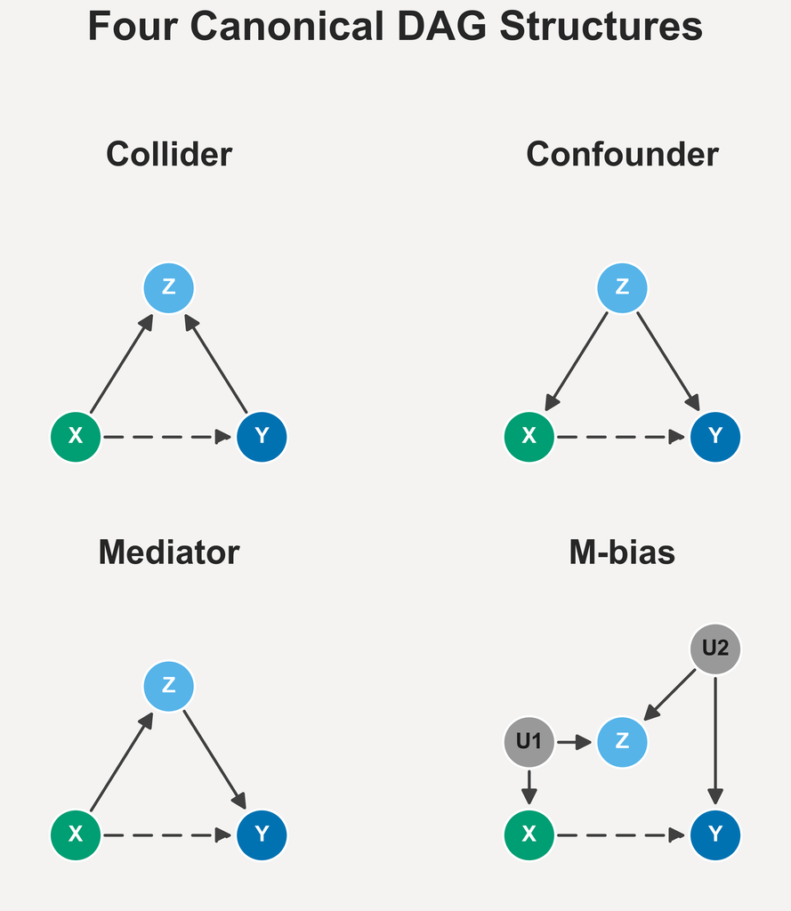

# Experiments

## What is an experiment?

- Manipulating a treatment variable in a controlled condition
- An intervention intended to establish a causal relationship

## Does social pressure affect voter turnout?

- Gerber, Green, and Larimer (2008), “Social Pressure and Voter Turnout: Evidence from a Large-Scale Field Experiment,” *APSR*
- Michigan voters were randomly assigned to:
  - a. receive a message that induces social pressure to vote
  - b. receive nothing

## Does social pressure affect voter turnout?

> Dear Registered Voter: WHAT IF YOUR NEIGHBORS KNEW WHETHER YOU VOTED? . . . We’re sending this mailing to you and your neighbors to publicize who does and does not vote. The chart shows the names of some of your neighbors, showing which have voted in the past. After the August 8 election, we intend to mail an updated chart. You and your neighbors will all know who voted and who did not.

> DO YOUR CIVIC DUTY–VOTE!

## Dependent Variable

$$Y_i = 1 \text{ if voted, } 0 \text{ if didn't vote}$$

## Treatment Variables

$$X_i = 1 \text{ if treated, } 0 \text{ if not treated}$$

$$X_i = 1 \text{ if received message, } 0 \text{ if received nothing}$$

## Individual Causal Effects

$$\text{individual_effect}_i = \Delta Y_i = Y_i(X_i = 1) - Y_i(X_i = 0)$$

- $Y_i(X_i = 1)$ — the potential outcome for individual $i$ under the treatment condition
- $Y_i(X_i = 0)$ — the potential outcome for individual $i$ under the control condition
- $\Delta$ — change

## Individual Causal Effects

$$\Delta \text{voted}_i = \text{voted}_i(\text{pressure}_i = 1) - \text{voted}_i(\text{pressure}_i = 0)$$

- $\text{voted}_i(\text{pressure}_i = 1)$ — whether individual $i$ would vote after receiving the message
- $\text{voted}_i(\text{pressure}_i = 0)$ — whether individual $i$ would vote after *not* receiving the message

## The Fundamental Problem of Causal Inference

- We never observe both the treatment and control outcomes for an individual
- We only observe the *factual* outcome, but never observe the *counterfactual* outcome

## Average Causal Effects

- The *average causal effect* of $X$ on $Y$ is the average change in $Y$ caused by a one-unit increase in $X$ for a group of individuals
- Average of all the individual causal effects
- How do we calculate the average causal effect if we don’t observe individual effects?

## Estimating Average Causal Effects

- Divide our experiment into two groups
  - Treatment group
  - Control group
- If the treatment and control groups are comparable, we can approximate the average causal effect by comparing the average outcome in the treatment group to the average outcome in the control group

# Randomized Experiments

## Randomized Experiments

*A randomized experiment is a research design in which the treatment assignment is determined through a random process.*

- What do we call a study where the treatment is out of control of the researcher?
  - Observational studies

## Random Treatment Assignment

- One of the most important concepts in science!
- Why?
  - Random treatment assignment makes the treatment and control groups identical, on average, in all observed and unobserved pre-treatment characteristics
  - $n$ must be large enough

## Difference-In-Means Estimator

When the treatment and control groups are comparable, we can estimate the average causal effect with the difference-in-means estimator:

$$\widehat{\text{average_causal_effect}} = \bar{Y}_{\text{treatment_group}} - \bar{Y}_{\text{control_group}}$$

## Summary

$$\text{individual_effect}_i = \Delta Y_i = Y_i(X_i = 1) - Y_i(X_i = 0)$$

- $Y_i(X_i = 1)$ — the potential outcome for individual $i$ under the treatment condition
- $Y_i(X_i = 0)$ — the potential outcome for individual $i$ under the control condition

**Problem:** We can never observe both

$$\text{average_effect} = \overline{\Delta Y} = \overline{Y(X = 1)} - \overline{Y(X = 0)}$$

- $\overline{Y(X = 1)}$ — the average potential outcome under the treatment condition
- $\overline{Y(X = 0)}$ — the average potential outcome under the control condition

**Problem:** We still never observe the counterfactual

## Summary

Through random assignment, we can make two groups comparable. When two groups are comparable, the factual outcome of one group is an unbiased estimate of the counterfactual outcome of the other. Thus:

$$\widehat{\text{average_causal_effect}} = \bar{Y}_{\text{treatment_group}} - \bar{Y}_{\text{control_group}}$$

The “hat” indicates that the `average_causal_effect` is a sample statistic, or an estimate.